# **Gisma University of Applied Sciences School of Computer Science M606Machine Learning**

# **Executive summary**

This project is a complete credit card fraud detection machine learning pipeline on a real-world dataset. This study uses various data preprocessing techniques, exploratory data analysis, feature engineering and classification algorithms such as Logistic Regression and Random Forest. From the results, it can be seen that the performance of the Random Forest is more accurate and has better recall in detecting fraudulent transactions than other classifiers. The model assists financial institutions in detecting suspicious activity, minimising financial damages and enhancing security. The solution showcases the power of machine learning for implementing real-time fraud detection systems.

# **1. Introduction**

**Problem Statement**

The identified issue is to develop an ML model to detect fraudulent credit card payments with high accuracy, while minimising financial losses due to its ability for effectively detect anomalous credit card transaction behaviour patterns.

**Data Analysis Structure**

Analysis covers data exploration, preprocessing, feature engineering, model training and evaluation (with various metrics), clustering analysis and interpreting the detection of fraud for insights.

# **2. Dataset Description**

# **Import Libraries**

```python
import pandas as pd
import numpy as np
import matplotlib.pyplot as plt
import seaborn as sns

from sklearn.model_selection import train_test_split
from sklearn.preprocessing import StandardScaler

from sklearn.linear_model import LogisticRegression
from sklearn.ensemble import RandomForestClassifier

from sklearn.cluster import KMeans
from sklearn.decomposition import PCA

from sklearn.metrics import classification_report, confusion_matrix, accuracy_score, roc_auc_score
import warnings
warnings.filterwarnings('ignore')
```

The image displays Python code running essential machine learning libraries, such as pandas, numpy, matplotlib, and seaborn, for data manipulation and visualisation. The code also included details about the sklearn modules used for data preprocessing, model training, clustering, dimensionality reduction, and evaluation metrics employed in the fraud detection pipeline.

# **Load Dataset**

```python
Credit_card_data = pd.read_csv("creditcard.csv")

Credit_card_data.head()
```

|  | Time | V1 | V2 | V3 | V4 | V5 | V6 | V7 | V8 | V9 | ... | V21 | V22 | V23 | V24 | V25 | V26 | V27 | V28 | Amount | Class |
| --- | --- | --- | --- | --- | --- | --- | --- | --- | --- | --- | --- | --- | --- | --- | --- | --- | --- | --- | --- | --- | --- |
| 0 | 0.0 | -1.359807 | -0.072781 | 2.536347 | 1.378155 | -0.338321 | 0.462388 | 0.239599 | 0.098698 | 0.363787 | ... | -0.018307 | 0.277838 | -0.110474 | 0.066928 | 0.128539 | -0.189115 | 0.133558 | -0.021053 | 149.62 | 0 |
| 1 | 0.0 | 1.191857 | 0.266151 | 0.166480 | 0.448154 | 0.060018 | -0.082361 | -0.078803 | 0.085102 | -0.255425 | ... | -0.225775 | -0.638672 | 0.101288 | -0.339846 | 0.167170 | 0.125895 | -0.008983 | 0.014724 | 2.69 | 0 |
| 2 | 1.0 | -1.358354 | -1.340163 | 1.773209 | 0.379780 | -0.503198 | 1.800499 | 0.791461 | 0.247676 | -1.514654 | ... | 0.247998 | 0.771679 | 0.909412 | -0.689281 | -0.327642 | -0.139097 | -0.055353 | -0.059752 | 378.66 | 0 |
| 3 | 1.0 | -0.966272 | -0.185226 | 1.792993 | -0.863291 | -0.010309 | 1.247203 | 0.237609 | 0.377436 | -1.387024 | ... | -0.108300 | 0.005274 | -0.190321 | -1.175575 | 0.647376 | -0.221929 | 0.062723 | 0.061458 | 123.50 | 0 |
| 4 | 2.0 | -1.158233 | 0.877737 | 1.548718 | 0.403034 | -0.407193 | 0.095921 | 0.592941 | -0.270533 | 0.817739 | ... | -0.009431 | 0.798278 | -0.137458 | 0.141267 | -0.206010 | 0.502292 | 0.219422 | 0.215153 | 69.99 | 0 |

5 rows × 31 columns

The transactions collected include credit card transactions for a total of 284,807 transaction records and 31 features, such as Time, Amount, or Class. Features V1 to V28 represent transformed variables. Structured numerical data displayed in a preview for fraud detection modelling and analysis.

# **Dataset Overview**

```python
Credit_card_data.info()
```

```
<class 'pandas.core.frame.DataFrame'>
RangeIndex: 284807 entries, 0 to 284806
Data columns (total 31 columns):
 #   Column  Non-Null Count   Dtype
---  ------  --------------   -----
 0   Time    284807 non-null  float64
 1   V1      284807 non-null  float64
 2   V2      284807 non-null  float64
 3   V3      284807 non-null  float64
 4   V4      284807 non-null  float64
 5   V5      284807 non-null  float64
 6   V6      284807 non-null  float64
 7   V7      284807 non-null  float64
 8   V8      284807 non-null  float64
 9   V9      284807 non-null  float64
```

[output cut: 23 more lines]

This data set contains 284,807 numeric data entries and 31 columns. The features are mostly float64, and the target variable, Class, is an integer. There are no missing values, which guarantees the completeness and appropriateness of the data for machine learning preprocessing and modelling operations.

```python
Credit_card_data.isnull().sum()
```

```
Time      0
V1        0
V2        0
V3        0
V4        0
V5        0
V6        0
V7        0
V8        0
V9        0
V10       0
V11       0
V12       0
V13       0
V14       0
V15       0
V16       0
V17       0
V18       0
V19       0
V20       0
V21       0
V22       0
V23       0
V24       0
V25       0
V26       0
V27       0
V28       0
Amount    0
Class     0
dtype: int64
```

All data points are complete across all columns, such as Time, V1-V28, Amount, and Class. This validates that the data quality is high and removes the need to impute, thus providing a clean data set which is ready for analysis and modelling.

# **3. Exploratory Data Analysis (EDA)**

# **Summary**

```python
Credit_card_data.describe()
```

|  | Time | V1 | V2 | V3 | V4 | V5 | V6 | V7 | V8 | V9 | ... | V21 | V22 | V23 | V24 | V25 | V26 | V27 | V28 | Amount | Class |
| --- | --- | --- | --- | --- | --- | --- | --- | --- | --- | --- | --- | --- | --- | --- | --- | --- | --- | --- | --- | --- | --- |
| count | 284807.000000 | 2.848070e+05 | 2.848070e+05 | 2.848070e+05 | 2.848070e+05 | 2.848070e+05 | 2.848070e+05 | 2.848070e+05 | 2.848070e+05 | 2.848070e+05 | ... | 2.848070e+05 | 2.848070e+05 | 2.848070e+05 | 2.848070e+05 | 2.848070e+05 | 2.848070e+05 | 2.848070e+05 | 2.848070e+05 | 284807.000000 | 284807.000000 |
| mean | 94813.859575 | 1.168375e-15 | 3.416908e-16 | -1.379537e-15 | 2.074095e-15 | 9.604066e-16 | 1.487313e-15 | -5.556467e-16 | 1.213481e-16 | -2.406331e-15 | ... | 1.654067e-16 | -3.568593e-16 | 2.578648e-16 | 4.473266e-15 | 5.340915e-16 | 1.683437e-15 | -3.660091e-16 | -1.227390e-16 | 88.349619 | 0.001727 |
| std | 47488.145955 | 1.958696e+00 | 1.651309e+00 | 1.516255e+00 | 1.415869e+00 | 1.380247e+00 | 1.332271e+00 | 1.237094e+00 | 1.194353e+00 | 1.098632e+00 | ... | 7.345240e-01 | 7.257016e-01 | 6.244603e-01 | 6.056471e-01 | 5.212781e-01 | 4.822270e-01 | 4.036325e-01 | 3.300833e-01 | 250.120109 | 0.041527 |
| min | 0.000000 | -5.640751e+01 | -7.271573e+01 | -4.832559e+01 | -5.683171e+00 | -1.137433e+02 | -2.616051e+01 | -4.355724e+01 | -7.321672e+01 | -1.343407e+01 | ... | -3.483038e+01 | -1.093314e+01 | -4.480774e+01 | -2.836627e+00 | -1.029540e+01 | -2.604551e+00 | -2.256568e+01 | -1.543008e+01 | 0.000000 | 0.000000 |
| 25% | 54201.500000 | -9.203734e-01 | -5.985499e-01 | -8.903648e-01 | -8.486401e-01 | -6.915971e-01 | -7.682956e-01 | -5.540759e-01 | -2.086297e-01 | -6.430976e-01 | ... | -2.283949e-01 | -5.423504e-01 | -1.618463e-01 | -3.545861e-01 | -3.171451e-01 | -3.269839e-01 | -7.083953e-02 | -5.295979e-02 | 5.600000 | 0.000000 |
| 50% | 84692.000000 | 1.810880e-02 | 6.548556e-02 | 1.798463e-01 | -1.984653e-02 | -5.433583e-02 | -2.741871e-01 | 4.010308e-02 | 2.235804e-02 | -5.142873e-02 | ... | -2.945017e-02 | 6.781943e-03 | -1.119293e-02 | 4.097606e-02 | 1.659350e-02 | -5.213911e-02 | 1.342146e-03 | 1.124383e-02 | 22.000000 | 0.000000 |
| 75% | 139320.500000 | 1.315642e+00 | 8.037239e-01 | 1.027196e+00 | 7.433413e-01 | 6.119264e-01 | 3.985649e-01 | 5.704361e-01 | 3.273459e-01 | 5.971390e-01 | ... | 1.863772e-01 | 5.285536e-01 | 1.476421e-01 | 4.395266e-01 | 3.507156e-01 | 2.409522e-01 | 9.104512e-02 | 7.827995e-02 | 77.165000 | 0.000000 |
| max | 172792.000000 | 2.454930e+00 | 2.205773e+01 | 9.382558e+00 | 1.687534e+01 | 3.480167e+01 | 7.330163e+01 | 1.205895e+02 | 2.000721e+01 | 1.559499e+01 | ... | 2.720284e+01 | 1.050309e+01 | 2.252841e+01 | 4.584549e+00 | 7.519589e+00 | 3.517346e+00 | 3.161220e+01 | 3.384781e+01 | 25691.160000 | 1.000000 |

8 rows × 31 columns

The descriptive statistics summary are summarised in descriptive statistics with its details miniature, maximum, quartiles, mean, and count. EDA is used to detect crucial correlations, patterns, and anomalies within the data, helping to inform the selection of features and the comprehension of the model (Ekbote et al., 2023). Highlights scaled variables and PCA components. The data set highlights variation and proves the effectiveness of the modelling process for fraud detection through normalisation and transformation.

# **Class Distribution (Pie Chart)**

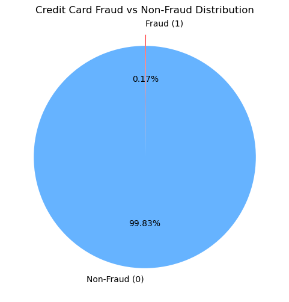

```python
class_counts = Credit_card_data['Class'].value_counts()

plt.figure(figsize=(6,6))

colors = ['#66b3ff', '#ff6666']

plt.pie(
    class_counts,
    labels=['Non-Fraud (0)', 'Fraud (1)'],
    autopct='%1.2f%%',
    startangle=90,
    colors=colors,
    explode=(0, 0.1)
)

plt.title("Credit Card Fraud vs Non-Fraud Distribution")
plt.show()
```

The pie chart clearly represents the extreme class imbalance in the dataset between the fraudulent and non-fraudulent transaction information for analysis. This imbalance suggests that fraud detection applications would benefit from using resampling methods such as SMOTE to boost the model's performance effectively.

# **Transaction Amount Distribution**

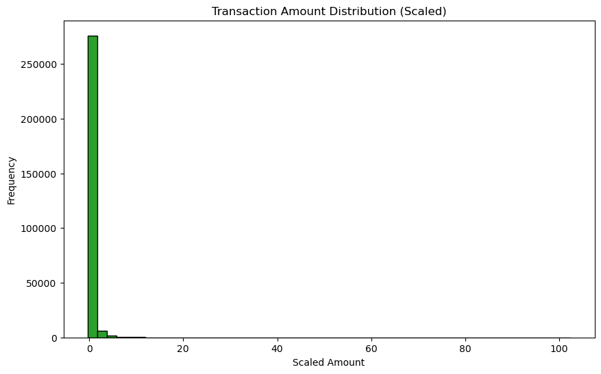

```python
scaler = StandardScaler()
Credit_card_data_temp = Credit_card_data.copy()
Credit_card_data_temp['Amount_scaled'] = scaler.fit_transform(Credit_card_data_temp[['Amount']])

plt.figure(figsize=(10,6))

plt.hist(
    Credit_card_data_temp['Amount_scaled'],
    bins=50,
    color='#2ca02c',
    edgecolor='black'
)

plt.title("Transaction Amount Distribution (Scaled)")
plt.xlabel("Scaled Amount")
plt.ylabel("Frequency")

plt.show()
```

Histograms depict the distribution of scaled transaction amounts, with the distribution being highly skewed to the right, with many values concentrated at the zero region. This means that there are few large transactions and many small transactions, and a few large transactions that might be considered abnormal or a potential pattern of fraud were detected.

# **Correlation Heatmap**

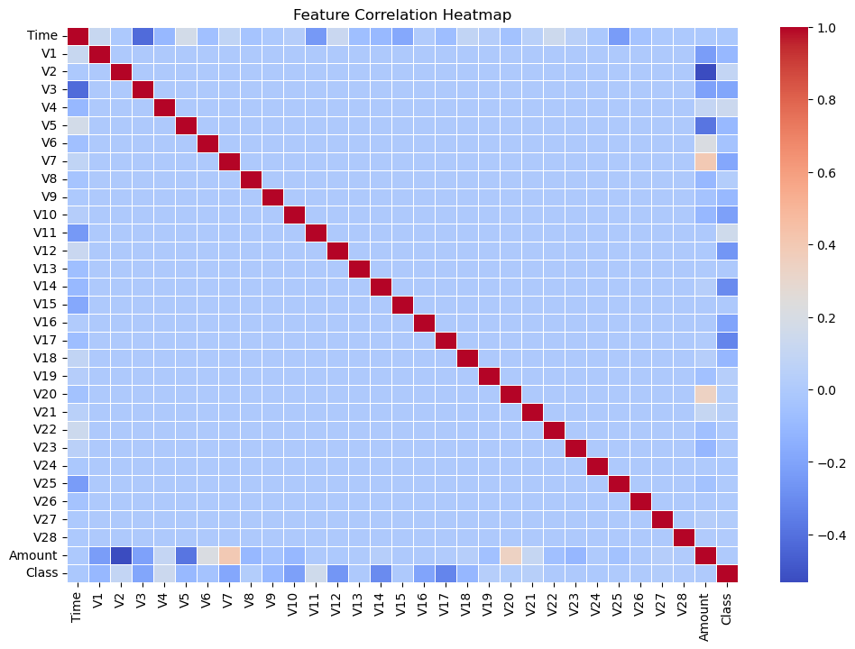

```python
plt.figure(figsize=(12,8))

corr = Credit_card_data.corr()

sns.heatmap(
    corr,
    cmap='coolwarm',
    annot=False,
    linewidths=0.5
)

plt.title("Feature Correlation Heatmap")
plt.show()
```

# **Top Feature Variance**

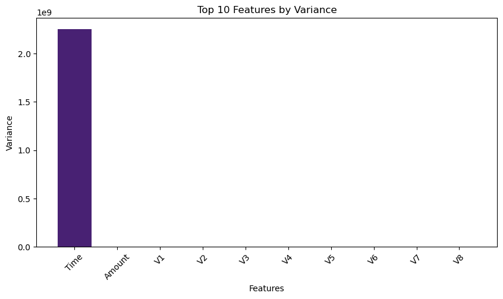

```python
feature_variance = Credit_card_data.var().sort_values(ascending=False).head(10)

plt.figure(figsize=(10,5))

colors = sns.color_palette("viridis", len(feature_variance))

plt.bar(feature_variance.index, feature_variance.values, color=colors)

plt.xticks(rotation=45)
plt.title("Top 10 Features by Variance")
plt.xlabel("Features")
plt.ylabel("Variance")

plt.show()
```

# **Fraud vs Non-Fraud Amount Comparison**

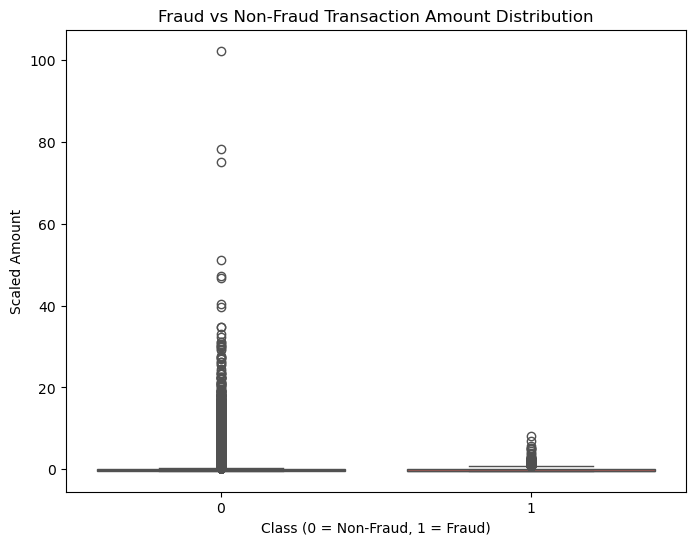

```python
scaler = StandardScaler()
Credit_card_data['Amount_scaled'] = scaler.fit_transform(Credit_card_data[['Amount']])

plt.figure(figsize=(8,6))

sns.boxplot(
    x='Class',
    y='Amount_scaled',
    data=Credit_card_data,
    palette=['#3498db', '#e74c3c']
)

plt.title("Fraud vs Non-Fraud Transaction Amount Distribution")
plt.xlabel("Class (0 = Non-Fraud, 1 = Fraud)")
plt.ylabel("Scaled Amount")

plt.show()
```

The box plot for Fraud vs Non-Fraud compares transactions with respect to the value of various transactions across both groups, making it easy to tell the distribution of both and clearly identify the extreme values. In cases of fraud, there are fewer transactions and the amount of transactions is lower, and in cases of non-fraud, there are more cases with high variance and spread.

# **Class Distribution (Imbalance Check)**

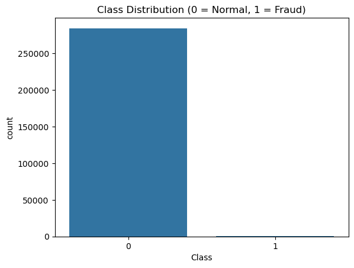

```python
sns.countplot(x='Class', data=Credit_card_data)
plt.title("Class Distribution (0 = Normal, 1 = Fraud)")
plt.show()
```

The class distribution bar chart reflects that it is a highly imbalanced dataset, with non-fraud transactions much more common than fraud cases are easily seen. This imbalance is one of the big problems in fraud detection, and is an issue that needs careful analysis of the quality of the models and careful re-sampling to ensure that they are fair with respect to their accuracy.

# **Feature Scaling**

```python
scaler = StandardScaler()

Credit_card_data['Amount_scaled'] = scaler.fit_transform(Credit_card_data[['Amount']])

Credit_card_data.drop(['Amount', 'Time'], axis=1, inplace=True)
```

Feature engineering uses StandardScaler to scale the transaction Amount into a scaled feature (Amount_scaled) for better model results. The original Amount and Time columns are eliminated in order to avoid bias and repetition, and to provide a uniform distribution of features for the machine learning algorithms.

# **Define Features and Target**

```python
X = Credit_card_data.drop('Class', axis=1)
y = Credit_card_data['Class']
```

The data is AgGlom into variables for independent variables (X) and dependent variable (Y). All features are designated as X, and fraud detection labels (Class) are designated as the target variable. This step is done to prepare Data for training a supervised machine learning model.

# **Train-Test Split**

```python
X_train, X_test, y_train, y_test = train_test_split(X, y, test_size=0.2, random_state=42, stratify=y)
```

The dataset is split into training & testing subsets using an 80/20 split. Stratified sampling provides for a balance between fraud and non-fraud cases. In credit card fraud detection, data preprocessing guarantees that the input data is clean and structured, which helps reduce noise in the system and boosts its effectiveness (Khalid et al., 2024). Data preparation avoids overfitting and gives you the ability to check the performance of the model on some data that its designed to be good on, for independent assessment for how reliable the model is.

# **Logistic Regression Model**

```python
log_model = LogisticRegression(max_iter=1000)
log_model.fit(X_train, y_train)
```

```
LogisticRegression(max_iter=1000)
```

```python
y_pred_log = log_model.predict(X_test)
```

The Logistic Regression model is then fitted to a training set (X_train, y_train) that has been used to train it, with a maximum of 1000 iterations for it to converge. The model identifies the transactions as fraud or non-fraud with a linear decision surface. The model forms a linear decision surface for the two classes, along with fraud. On test data, predictions are made by the predict function to be evaluated.

# **Random Forest Model**

```python
rf_model = RandomForestClassifier(n_estimators=100, random_state=42)
rf_model.fit(X_train, y_train)
```

```
RandomForestClassifier(random_state=42)
```

```python
y_pred_rf = rf_model.predict(X_test)
```

# **Model Evaluation – Logistic Regression**

```python
print("Logistic Regression Accuracy:", accuracy_score(y_test, y_pred_log))
print("ROC AUC Score:", roc_auc_score(y_test, y_pred_log))

print(confusion_matrix(y_test, y_pred_log))
print(classification_report(y_test, y_pred_log))
```

```
Logistic Regression Accuracy: 0.9991573329588147
ROC AUC Score: 0.8213142636063991
[[56851    13]
 [   35    63]]
              precision    recall  f1-score   support

           0       1.00      1.00      1.00     56864
           1       0.83      0.64      0.72        98

    accuracy                           1.00     56962
   macro avg       0.91      0.82      0.86     56962
weighted avg       1.00      1.00      1.00     56962
```

# **Confusion Matrix Visualization**

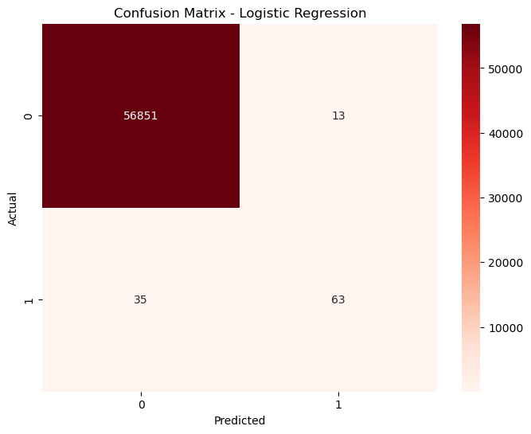

```python
cm_log = confusion_matrix(y_test, y_pred_log)

plt.figure(figsize=(8,6))
sns.heatmap(cm_log, annot=True, fmt='d', cmap='Reds')
plt.title("Confusion Matrix - Logistic Regression")
plt.xlabel("Predicted")
plt.ylabel("Actual")
plt.show()
```

A good accuracy was obtained for the non-fraud class with 56851 correct predictions, as provided in the confusion matrix. But in terms of fraud detection, 35 frauds are missed, 63 are detected, and 13 are false alarms, suggesting that imbalanced data has a great impact on the sensitivity of the model in detecting minority frauds.

# **Model Evaluation – Random Forest**

```python
print("Random Forest Accuracy:", accuracy_score(y_test, y_pred_rf))
print("ROC AUC Score:", roc_auc_score(y_test, y_pred_rf))

print(confusion_matrix(y_test, y_pred_rf))
print(classification_report(y_test, y_pred_rf))
```

```
Random Forest Accuracy: 0.9996137776061234
ROC AUC Score: 0.9132213415754596
[[56859     5]
 [   17    81]]
              precision    recall  f1-score   support

           0       1.00      1.00      1.00     56864
           1       0.94      0.83      0.88        98

    accuracy                           1.00     56962
   macro avg       0.97      0.91      0.94     56962
weighted avg       1.00      1.00      1.00     56962
```

Random Forest gives 99.96% accuracy and has a better ROC AUC score at 0.91. The confusion matrix is as follows: 56859 true negatives, 81 true positives, 5 false positives, and 17 false negatives. Compared to Logistic Regression, the model can do a better job in detecting fraud.

# **Confusion Matrix Visualization**

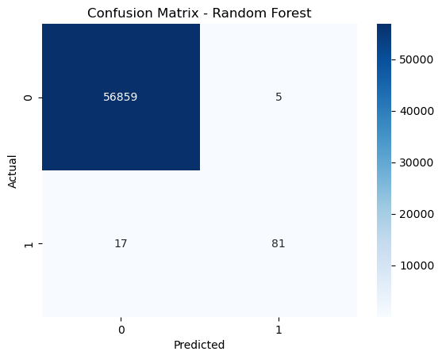

```python
cm = confusion_matrix(y_test, y_pred_rf)

sns.heatmap(cm, annot=True, fmt='d', cmap='Blues')
plt.title("Confusion Matrix - Random Forest")
plt.xlabel("Predicted")
plt.ylabel("Actual")
plt.show()
```

The Random Forest comparison matrix displays very good results with 56859 true non-fraud predictions. 81 true positives and 17 fewer false negatives, with just 5 false positives, provide better security for detecting rare fraudulent transactions successfully.

# **Feature Importance (Random Forest)**

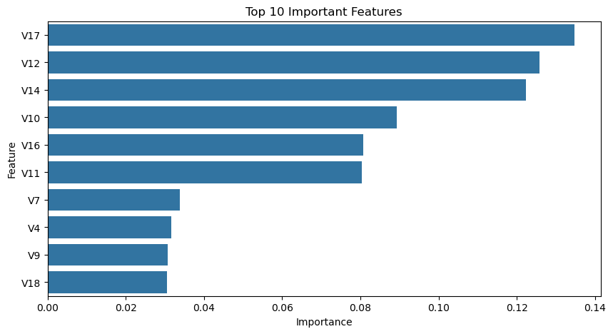

```python
importance = rf_model.feature_importances_

feature_importance = pd.DataFrame({
    'Feature': X.columns,
    'Importance': importance
}).sort_values(by='Importance', ascending=False)

plt.figure(figsize=(10,5))
sns.barplot(x='Importance', y='Feature', data=feature_importance.head(10))
plt.title("Top 10 Important Features")
plt.show()
```

# **K-MEANS UNSUPERVISED LEARNING**

# **Prepare Data for Clustering**

```python
X_cluster = Credit_card_data.drop('Class', axis=1)
```

The target column Class is omitted to form an unsupervised set of data for clustering. This way, only feature variables are utilised, and along the K-Means algorithm can discover concealed designs, segmenting comparable deals without preconceptions about fraud class labels efficiently.

# **Elbow Method (Optimal Clusters)**

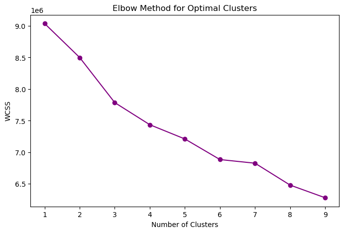

```python
wcss = []

for i in range(1, 10):
    kmeans = KMeans(n_clusters=i, random_state=42)
    kmeans.fit(X_cluster)
    wcss.append(kmeans.inertia_)

plt.figure(figsize=(8,5))
plt.plot(range(1, 10), wcss, marker='o', color='purple')
plt.title("Elbow Method for Optimal Clusters")
plt.xlabel("Number of Clusters")
plt.ylabel("WCSS")
plt.show()
```

# **Apply K-Means Clustering**

```python
kmeans = KMeans(n_clusters=2, random_state=42)
Credit_card_data['Cluster'] = kmeans.fit_predict(X_cluster)
```

```python
Credit_card_data.head()
```

|  | V1 | V2 | V3 | V4 | V5 | V6 | V7 | V8 | V9 | V10 | ... | V22 | V23 | V24 | V25 | V26 | V27 | V28 | Class | Amount_scaled | Cluster |
| --- | --- | --- | --- | --- | --- | --- | --- | --- | --- | --- | --- | --- | --- | --- | --- | --- | --- | --- | --- | --- | --- |
| 0 | -1.359807 | -0.072781 | 2.536347 | 1.378155 | -0.338321 | 0.462388 | 0.239599 | 0.098698 | 0.363787 | 0.090794 | ... | 0.277838 | -0.110474 | 0.066928 | 0.128539 | -0.189115 | 0.133558 | -0.021053 | 0 | 0.244964 | 0 |
| 1 | 1.191857 | 0.266151 | 0.166480 | 0.448154 | 0.060018 | -0.082361 | -0.078803 | 0.085102 | -0.255425 | -0.166974 | ... | -0.638672 | 0.101288 | -0.339846 | 0.167170 | 0.125895 | -0.008983 | 0.014724 | 0 | -0.342475 | 0 |
| 2 | -1.358354 | -1.340163 | 1.773209 | 0.379780 | -0.503198 | 1.800499 | 0.791461 | 0.247676 | -1.514654 | 0.207643 | ... | 0.771679 | 0.909412 | -0.689281 | -0.327642 | -0.139097 | -0.055353 | -0.059752 | 0 | 1.160686 | 0 |
| 3 | -0.966272 | -0.185226 | 1.792993 | -0.863291 | -0.010309 | 1.247203 | 0.237609 | 0.377436 | -1.387024 | -0.054952 | ... | 0.005274 | -0.190321 | -1.175575 | 0.647376 | -0.221929 | 0.062723 | 0.061458 | 0 | 0.140534 | 0 |
| 4 | -1.158233 | 0.877737 | 1.548718 | 0.403034 | -0.407193 | 0.095921 | 0.592941 | -0.270533 | 0.817739 | 0.753074 | ... | 0.798278 | -0.137458 | 0.141267 | -0.206010 | 0.502292 | 0.219422 | 0.215153 | 0 | -0.073403 | 0 |

5 rows × 31 columns

K-Means Clustering is used to partition transactions into two clusters according to similarity patterns. A new column "Cluster" was added to the dataset to designate its membership in a cluster. This aids in discovering concealed patterns in credit card deals. There are two behavioural groups to differentiate by: Cluster 0 and Cluster 1.

# **PCA for 2D Visualization**

```python
pca = PCA(n_components=2)
pca_components = pca.fit_transform(X_cluster)

Credit_card_data['PCA1'] = pca_components[:, 0]
Credit_card_data['PCA2'] = pca_components[:, 1]
```

The Principal Component Analysis is used to compress high-dimensional transaction data down to two components of data: PCA1 and PCA2. These components summarise as much variation in data as possible and provide easier visualisation. The new PCA columns contribute to an enhanced separation of the clusters and the capability of defining the distribution of fraud and non-fraud transactions in reduced dimensional space in an easily interpretable way.

# **Cluster Visualization (Colored Plot with Labels)**

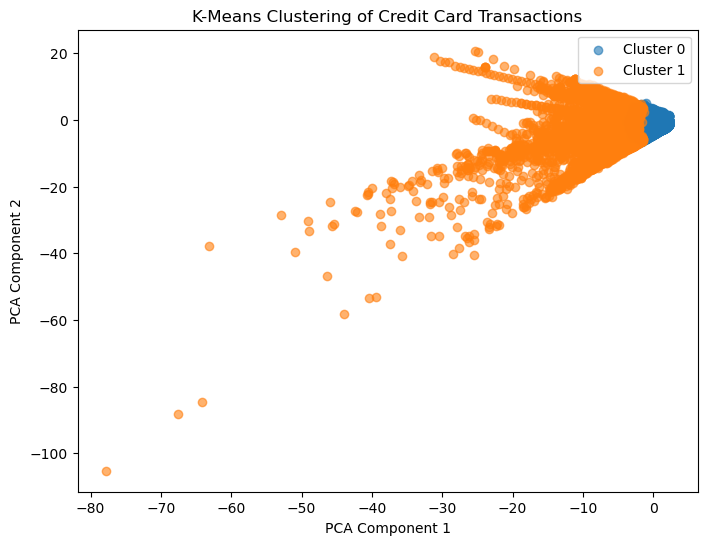

```python
plt.figure(figsize=(8,6))

colors = ['#1f77b4', '#ff7f0e']

for i in range(2):
    clustered_data = Credit_card_data[Credit_card_data['Cluster'] == i]
    plt.scatter(
        clustered_data['PCA1'],
        clustered_data['PCA2'],
        label=f'Cluster {i}',
        color=colors[i],
        alpha=0.6
    )

plt.title("K-Means Clustering of Credit Card Transactions")
plt.xlabel("PCA Component 1")
plt.ylabel("PCA Component 2")
plt.legend()
plt.show()
```

The PCA scatter plot shows two clusters formed using the K-Means algorithm. There is a visual separation between Cluster 0 and Cluster 1, although there is some overlap because there are complex transactions. PCA components are one way to visualise high-dimensional data in two dimensions, facilitating interpretation of the distribution of clusters and related groupings of clusters that may have relevance for fraud or otherwise.

# **8. Results and Discussion**

The following features, centred around the Random Forest feature importance plot, are the most important and will influence prediction: V17, the V12, the V14, the V10 feature. These features capture behavior patterns that occur within transactions, which cannot be seen, that distinguish a fraudulent transaction from a legitimate one. Feature importance analysis is used to explain their models, gaining insight into which features contribute most to the predictions; though more advanced methods of SHAP analysis could also improve the model's interpretability.

These are the main advantages of the model: high accuracy, a good generalisation ability, noise resistance, and good ability to deal with non-linear relationships in financial transactions. The hidden structures in the transaction data can be visualised using clustering and PCA techniques, thus making the results of frauds detection more interpretable (Gowda et al., 2024). Further, PCA and clustering increases the understanding of the data and the discovery of patterns. But there are constraints on the extent they can be diverse, as there are extreme class imbalance that can bias the model to predict non-fraud transactions. Logistic Regression has a lesser rate of recall than our other model, Random Forest. Transformed features (V1-V28) may introduce some level of potential bias between the features being compared. Future enhancements involve SMOTE balancing, explainability using SHAP and a Threshold Tuner to boost the sensitivity of the fraud detection system.

# **9. Business Implications**

The outcome of this machine learning model directly solve the business issue of real-time detection of fraudulent credit card transactions. The model assists financial institutions in detecting valid and fraudulent transactions with a high level of accuracy, which decreases financial damages and customers' distrust in the institution. In particular, the Random Forest has a high capability in detecting frauds; hence it could be used in the real-world banking system. In practical deployment the model's outputs can be plugged into tools for fraud monitoring which label, or risk score, each transaction. Manual review of the transaction or automatic blocking of transactions is possible. Transactions flagged as high-risk are subject to manual checks, and the low-risk transactions are approved immediately (Aidoo et al., 2023). This increases the efficiency of operations and simplifies investigations without manual processes. Centrally, the model allows data-driven fraud prevention strategies from a decision-making point of view. Banks can optimise their transaction monitoring thresholds, deployment of inspection resources optimisation and early detection of prospective and risky behavioural patterns (Islam, 2025). The feature importance results can also help risk analysts to gain insight into the type of fraud indicators, such as transaction behaviour anomalies. From a cost perspective the model minimises the losses incurred from fraudulent transactions and lowers the expenses incurred in those expenses and placed in the system. There's also a boost to customer satisfaction as fraud is detected faster, which prevents misuse of accounts. The system improves security, efficiency, and profitability, making it a valuable asset in today's financial risk management and fraud prevention efforts.

# **10. Deployment Considerations**

Implementing the credit card fraud detection model necessitates proper planning to make it capable of thriving in real-world fiscal environments. A trained RF can be incorporated into a banking transaction monitoring system with an architecture based on APIs (Gunda, 2025). This returns to the ability for real-time prediction of incoming transactions; for each transaction, the trained patterns predict fraud or non-fraud status instantly. The model needs to be deployed on a scalable cloud platform like AWS, Azure, or Google Cloud which can run the model to manage the large volume of transactions efficiently. A REST API can be developed using frameworks like Flask or FastAPI to connect the model with banking applications. The system should also maintain an automatic log of predictions and see any time drift so these predictions can be monitored. Post-deployment monitoring to maintain the accuracy of model results is critical, particularly in this context of changing fraud patterns and evolution. It is advisable to frequently retrain using new transactions to improve performance. The security is important like encryption, authentication and access control, these need to safeguard sensitive financial information (Omotunde and Ahmed, 2023). Other key areas to consider are latency fraud detection must come as quickly as transactions are made and in real time, without interfering with what is actually happening. Hence it is an important issue to optimise the model and make an efficient design of infrastructure (commonly called an infrastructure). In summary, a carefully thought-out deployment strategy will lead to scalable, reliable, and secure production solutions with a higher degree of fraud protection.

# **11. Ethical Considerations**

This project addresses important ethics in data protection, privacy and financial systems regarding machine learning. Data on this dataset is also anonymised transaction data to ensure that no personally identifiable information (PII) is exposed. This corresponds to data protection principles as set out in the General Data Protection Regulation (GDPR) as well as the Data Protection Act 2018, specifically when it comes to processing personal data lawfully, fairly and securely. The data is anonymised, which minimises privacy concerns and allows for useful analysis for detecting fraud (Labadie and Legner, 2023). In addition, issues of ethics with regards to fairness & bias are crucial. The model needs to guarantee that predictions are not discriminating against particular groups of users. An effort is made to ensure that there is no biased decision-making by measuring performance for both classes (fraud and non-fraud). The project also abides by copyright rules according to the Copyright, Designs and Patents Act 1988, where all data sets, libraries and references are correctly referenced and used within appropriate academic/research parameters. Proprietary financial information and controlled information is not misused. In addition, aspects of transparency and explainability are regarded as important ethical aspects. Although machine learning models may be complex, understanding the relative importance of the features can be used to explain how the prediction is calculated which can help with levels of accountability (Kretschmer et al., 2022). In summary, this project is aligned with ethical considerations, responsible use of AI, and adherence to legal frameworks for fraud detection systems, thereby enhancing the capabilities of the AI program.

# **12. Conclusion**

In conclusion, the project is able to create a credit card fraud detection system based on machine learning models Logistic Regression and Random Forest. Analysis found that Random Forest yields excellent results when determining fraudulent transactions in particular scenarios, when dealing with imbalanced data sets. Data preprocessing, feature engineering and exploratory data analysis enhanced the accuracy and interpretability of the model. The results highlight the importance of advanced machine learning techniques in enhancing financial security systems. Overall, the model works well, enables real-time fraud detection and enhances financial risk mitigation, as well as efficiency in decision-making. Class imbalance can be further improved and techniques for explainable AI can be used for transparency improvements in future.

# **References**

Aidoo, S., AML, I.D., AML, M. and Expert, F.C.C., (2023). *Transaction Monitoring and Suspicious Activity Reporting (SAR)*. J. Financ. Crime Prev, 15, pp.112-130.

Ali, A., Abd Razak, S., Othman, S.H., Eisa, T.A.E., Al-Dhaqm, A., Nasser, M., Elhassan, T., Elshafie, H. and Saif, A., (2022). Financial fraud detection based on machine learning: a systematic literature review. *Applied Sciences*, 12(19), p.9637.

Ekbote, N., Dhanshetti, P. and Sakhrekar, S., (2023). Techniques of exploratory data analysis. *Madhya Pradesh Journal of Social Sciences*, 28(2), pp.10-14.

Gowda, S., Kunjar, V., Gupta, A., Kavitha, G., Shukla, B.K. and Sihag, P., (2024). Prediction of the subgrade soil California bearing ratio using machine learning and neuro-fuzzy inference system techniques: A sustainable approach in urban infrastructure development. *Urban Science*, 8(1), p.4.

Gunda, S.K., (2025). AI-Enhanced API Reliability Testing for Digital Banking: Improving Accuracy, Resilience, and Integrity in Financial Transaction Processing. *International Journal of Emerging Trends in Computer Science and Information Technology*, 6(2), pp.136-143.

Islam, S., (2025). Machine Learning–Based AML/KYC Transaction Monitoring for Suspicious Activity Detection and Compliance Risk Reduction in Digital Banking. *ASRC Procedia: Global Perspectives in Science and Scholarship*, 1(01), pp.1740-1775.

Khalid, A.R., Owoh, N., Uthmani, O., Ashawa, M., Osamor, J. and Adejoh, J., (2024). Enhancing credit card fraud detection: an ensemble machine learning approach. *Big Data and Cognitive Computing*, 8(1), p.6.

Kretschmer, M., Meletti, B. and Porangaba, L.H., (2022). Artificial intelligence and intellectual property: copyright and patents—a response by the CREATe Centre to the UK Intellectual Property Office’s open consultation. *Journal of Intellectual Property Law and Practice*, 17(3), pp.321-326.

Labadie, C. and Legner, C., (2023). Building data management capabilities to address data protection regulations: Learnings from EU-GDPR. *Journal of Information Technology*, 38(1), pp.16-44.

Omotunde, H. and Ahmed, M., (2023). A comprehensive review of security measures in database systems: Assessing authentication, access control, and beyond. *Mesopotamian Journal of CyberSecurity*, 2023, pp.115-133.

Salunke, Y., Phalke, S., Madavi, M., Kumre, P. and Bobhate, G., (2025). Fraud detection: a hybrid approach with logistic regression, decision tree, and random forest. *Cureus J. Comp. Sci*, 2.

# **Appendix Github Link**

### https://github.com/annu81020/M606Machine-Learning.git